# Exploring the BRFSS data

SeungHeon DOh

2018.03.28

## Setup

### Load packages

```r
library(knitr)
library(pander)
library(ggplot2)
library(colorspace)
library(tidyr)
library(dplyr)
```

### Load data

Make sure your data and R Markdown files are in the same directory. When loaded your data file will be called `brfss2013`. Delete this note when before you submit your work.

```r
load("brfss2013.RData")
```

## Part 1: Data

The Behavioral Risk Factor Surveillance System (BRFSS) is an **observational study targeting the non-institutionalized adult population, aged 18 years or older** , who reside in the United States. The study is a retrospective observational study as it asks respondents about various aspects of their health in the previous months to their contact. The study’s observations are collected by **contacting respondents by phone calls** . **Random sampling** is used to select the phone numbers and which adult to question at each location.d. **No causality can be determined from this observational study, only associational relationships**. Any identified associations will also be complicated by lurking variables as it will be difficult to rule out other confounding factors that may lead to such associations. the sample size is **large** and data is representive of the US adult population so the study is **generalizable**, but the scope of inference is narrow and **causality can not be determined** considering these and other limitations of this observational study’s design.

#### In conclusion : data set is respondents by phone calls, andom sampling, No causality, only associational relationships, large, generalizable

#### load Data

```r
df = brfss2013
names(df)
```

```
##   [1] "X_state"   "fmonth"    "idate"     "imonth"    "iday"
##   [6] "iyear"     "dispcode"  "seqno"     "X_psu"     "ctelenum"
##  [11] "pvtresd1"  "colghous"  "stateres"  "cellfon3"  "ladult"
##  [16] "numadult"  "nummen"    "numwomen"  "genhlth"   "physhlth"
##  [21] "menthlth"  "poorhlth"  "hlthpln1"  "persdoc2"  "medcost"
##  [26] "checkup1"  "sleptim1"  "bphigh4"   "bpmeds"    "bloodcho"
##  [31] "cholchk"   "toldhi2"   "cvdinfr4"  "cvdcrhd4"  "cvdstrk3"
##  [36] "asthma3"   "asthnow"   "chcscncr"  "chcocncr"  "chccopd1"
##  [41] "havarth3"  "addepev2"  "chckidny"  "diabete3"  "veteran3"
##  [46] "marital"   "children"  "educa"     "employ1"   "income2"
##  [51] "weight2"   "height3"   "numhhol2"  "numphon2"  "cpdemo1"
##  [56] "cpdemo4"   "internet"  "renthom1"  "sex"       "pregnant"
##  [61] "qlactlm2"  "useequip"  "blind"     "decide"    "diffwalk"
##  [66] "diffdres"  "diffalon"  "smoke100"  "smokday2"  "stopsmk2"
##  [71] "lastsmk2"  "usenow3"   "alcday5"   "avedrnk2"  "drnk3ge5"
```

[output cut: 51 more lines]

```r
str(df)
```

```
## 'data.frame':    491775 obs. of  330 variables:
##  $ X_state  : Factor w/ 55 levels "0","Alabama",..: 2 2 2 2 2 2 2 2 2 2 ...
##  $ fmonth   : Factor w/ 12 levels "January","February",..: 1 1 1 1 2 3 3 3 4 4 ...
##  $ idate    : int  1092013 1192013 1192013 1112013 2062013 3272013 3222013 3042013 4242013 4242013 ...
##  $ imonth   : Factor w/ 12 levels "January","February",..: 1 1 1 1 2 3 3 3 4 4 ...
##  $ iday     : Factor w/ 31 levels "1","2","3","4",..: 9 19 19 11 6 27 22 4 24 24 ...
##  $ iyear    : Factor w/ 2 levels "2013","2014": 1 1 1 1 1 1 1 1 1 1 ...
##  $ dispcode : Factor w/ 2 levels "Completed interview",..: 1 1 1 1 1 1 1 1 1 1 ...
##  $ seqno    : int  2013000580 2013000593 2013000600 2013000606 2013000608 2013000630 2013000634 2013000644 2013001305 2013001338 ...
##  $ X_psu    : int  2013000580 2013000593 2013000600 2013000606 2013000608 2013000630 2013000634 2013000644 2013001305 2013001338 ...
##  $ ctelenum : Factor w/ 1 level "Yes": 1 1 1 1 1 1 1 1 1 1 ...
##  $ pvtresd1 : Factor w/ 2 levels "Yes","No": 1 1 1 1 1 1 1 1 1 1 ...
##  $ colghous : Factor w/ 1 level "Yes": NA NA NA NA NA NA NA NA NA NA ...
##  $ stateres : Factor w/ 1 level "Yes": 1 1 1 1 1 1 1 1 1 1 ...
##  $ cellfon3 : Factor w/ 1 level "Not a cellular phone": 1 1 1 1 1 1 1 1 1 1 ...
```

[output cut: 86 more lines]

## Part 2: Research questions

**Research quesion 1:**

variable: `_bmi5` (continuous) computed by researchers in kg/m^2 Relevance : In category of human, the min and max value of bmi is exist.And we need to find normal point of BMI.

**Research quesion 2:**

*Does a correlation exist between Are a having a lower reported income and reported days with poor physical health or poor mental health in the last 30 days?*

explanatory variable: `income2`(income level) response variables: `physhlth` and `menthlth` in days

**Research quesion 3:**

*Does a correlation exist between the body mass index(BMI) of the individual answering the survey and having cardiac stroke or having a heart attack? which one is more sensitive*

explanatory variable: `_bmi5` (continuous) computed by researchers in kg/m^2 response variables: `cvdstrk3` and `cvdinfr4`

Relevance : According to bmi5, people take difference in Number Of Days Physical Health Not Good, and cost problem

## Part 3: Exploratory data analysis

#### Research quesion 1:

```r
df$X_bmi5 = as.numeric(df$X_bmi5)/100
```

```r
summary(df$X_bmi5)
```

```
##    Min. 1st Qu.  Median    Mean 3rd Qu.    Max.    NA's
##    0.01   23.67   26.63   27.82   30.81   97.69   26727
```

```r
sd(df$X_bmi5, na.rm=TRUE)
```

```
## [1] 6.156677
```

```r
BMI = ggplot(df, aes(x=X_bmi5)) + theme_bw() + geom_histogram(binwidth=2, alpha=0.5, aes(y=..density..), fill="lightblue", col="grey") + stat_function(fun=dnorm, args=list(mean=26.63, sd=6.1566), col="red") + geom_rug() + labs(title="Distribution of BMI", x="BMI", y="Frequency")
```

[figure not shown]

```r
BMI
```

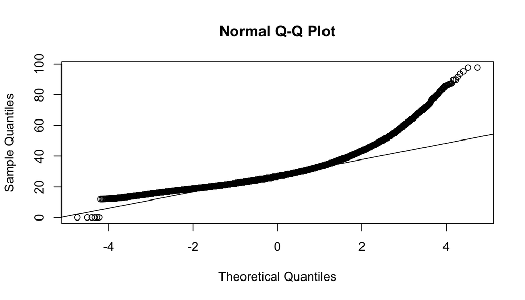

```r
qqnorm(df$X_bmi5)
qqline(df$X_bmi5)
```

The sample looks like it does not follow a normal distribution, it is seem to be not linear shape of the QQ plot. Regardless, we can use the Shapiro-Wilk normality test to assess this more thoroughly. The null hypothesis (Ho) is that the data follow a normal distribution, and we will reject the Ho if the p-value < 0.05 .

```r
shapiro.test(sample(df$X_bmi5, 5000))
```

```
##
##  Shapiro-Wilk normality test
##
## data:  sample(df$X_bmi5, 5000)
## W = 0.90433, p-value < 2.2e-16
```

**Conclusion** `p < 2.2e-16`, we can assume that this sample **does not follow a normal distribution.**

#### Research quesion 2:

*Does a correlation exist between Are a having a lower reported income and reported days with poor physical health or poor mental health in the last 30 days?*

```r
allprep <- function(...) {
    study <- brfss2013 %>%
        select(...)
    return(study[complete.cases(study),])
}
```

```r
dat2 <- allprep(physhlth, menthlth, income2)
pandoc.table(head(dat2), justify = "center")
```

```
##
## -----------------------------------------
##  physhlth   menthlth        income2
## ---------- ---------- -------------------
##     30         29      Less than $75,000
##
##     0          0        $75,000 or more
##
##     3          2        $75,000 or more
##
##     2          0       Less than $75,000
##
##     10         2       Less than $50,000
##
##     0          0        $75,000 or more
## -----------------------------------------
```

```r
summary(dat2$physhlth)
```

```
##    Min. 1st Qu.  Median    Mean 3rd Qu.    Max.
##   0.000   0.000   0.000   4.254   3.000  30.000
```

```r
summary(dat2$menthlth)
```

```
##    Min. 1st Qu.  Median    Mean 3rd Qu.    Max.
##   0.000   0.000   0.000   3.406   2.000 247.000
```

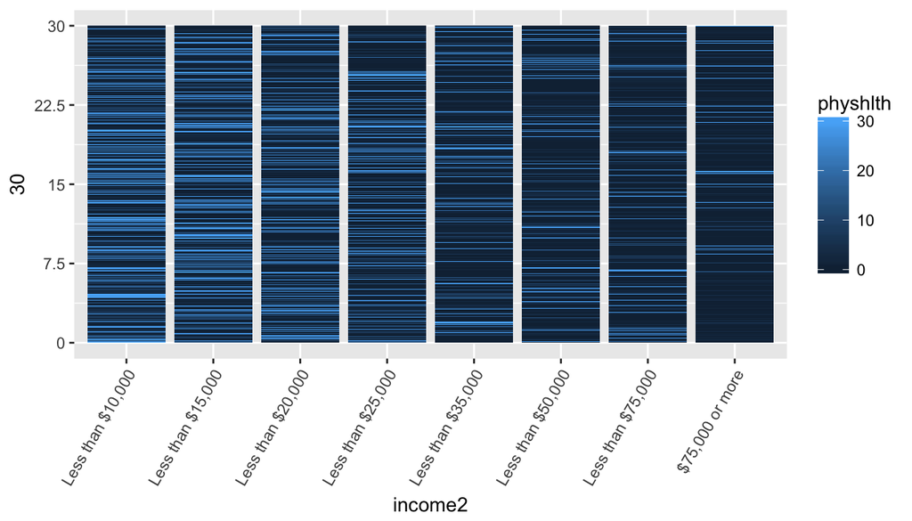

```r
ggplot(dat2, aes(x= income2, y = 30, fill = physhlth)) + geom_bar(stat="identity", position = "fill") +
  scale_y_continuous(labels = c("0", "7.5", "15", "22.5", "30")) +
  theme(axis.text.x = element_text(angle = 60, hjust = 1), plot.title = element_text(hjust = 0.5))
```

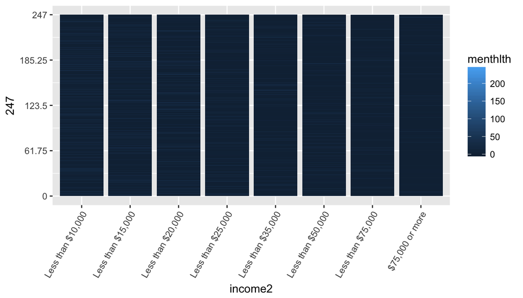

```r
ggplot(dat2, aes(x= income2, y = 247, fill = menthlth)) +
  geom_bar(stat="identity", position = "fill") +
  scale_y_continuous(labels = c("0", "61.75", "123.5", "185.25", "247")) +
  theme(axis.text.x = element_text(angle = 60, hjust = 1), plot.title = element_text(hjust = 0.5))
```

#### Research quesion 3:

*Does a correlation exist between the body mass index(BMI) of the individual answering the survey and having cardiac stroke or having a heart attack? which one is more sensitive*

explanatory variable: `_bmi5` (continuous) computed by researchers in kg/m^2 response variables: `cvdstrk3` and `cvdinfr4`

```r
summary(df$X_bmi5)
```

```
##    Min. 1st Qu.  Median    Mean 3rd Qu.    Max.    NA's
##    0.01   23.67   26.63   27.82   30.81   97.69   26727
```

```r
sd(df$X_bmi5, na.rm=TRUE)
```

```
## [1] 6.156677
```

```r
table(df$cvdstrk3)
```

```
##
##    Yes     No
##  20391 469917
```

```r
table(df$cvdinfr4)
```

```
##
##    Yes     No
##  29284 459904
```

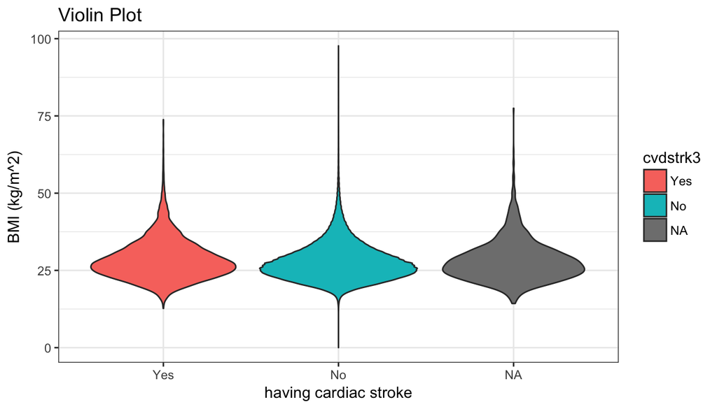

```r
ggplot(df, aes(x=cvdstrk3, y=X_bmi5, fill=cvdstrk3)) + theme_bw() +
 geom_violin() + labs(title="Violin Plot",
 x="having cardiac stroke", y="BMI (kg/m^2)")
```

```r
temp = filter(df, cvdstrk3=="Yes" | cvdstrk3=="No") %>% select(X_bmi5, cvdstrk3)
chisq.test(temp$X_bmi5, temp$cvdstrk3)
```

```
##
##  Pearson's Chi-squared test
##
## data:  temp$X_bmi5 and temp$cvdstrk3
## X-squared = 6586.5, df = 3847, p-value < 2.2e-16
```

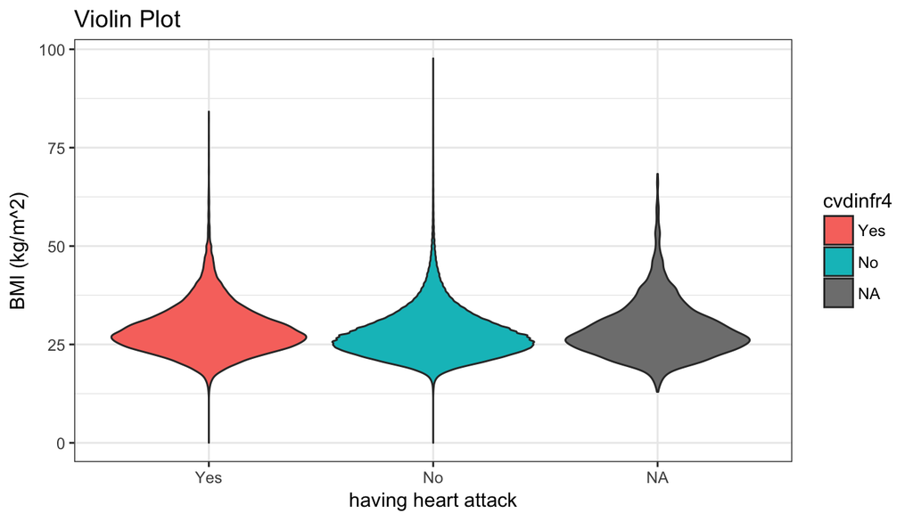

```r
ggplot(df, aes(x=cvdinfr4, y=X_bmi5, fill=cvdinfr4)) + theme_bw() +
 geom_violin() + labs(title="Violin Plot",
 x="having heart attack", y="BMI (kg/m^2)")
```

```r
temp = filter(df, cvdinfr4=="Yes" | cvdinfr4=="No") %>% select(X_bmi5, cvdinfr4)
chisq.test(temp$X_bmi5, temp$cvdinfr4)
```

```
##
##  Pearson's Chi-squared test
##
## data:  temp$X_bmi5 and temp$cvdinfr4
## X-squared = 7600.9, df = 3848, p-value < 2.2e-16
```